# index

## Principle conponent analysis (PCA)

Ali Arous

**The code included in this report can be downloaded from here: https://ali-arous.github.io/db/ex3part2/code.py**

### Exercise 1. example.dat

```python
import numpy as np
import numpy.linalg as la
import csv
with open('example.dat', 'r') as f:
    data = csv.reader(f, delimiter = ' ')
    A = np.array(list(data)).astype('float')
print('Original Data:')
print()
print(A)
A = A.T

def PCA_algo(A):
    X = A
    Y = 1/np.sqrt(X.shape[1] - 1) * X.T
    U, sigma, Vt = la.svd(Y, full_matrices=False)
    new_X = Vt.dot(X)
    print('Data in new PCA coordinates:')
    print()
    print(new_X.T.round(2))
    print('===========================')
    eigenv = sigma**2
    totalvar=eigenv.sum()
    for i in range(len(sigma)):
        print('Variance captured in PC'+str(i+1)+': ', str(np.round((eigenv[i]/totalvar*100),2))+'%',', Accumulative: ',str(np.round((np.sum(eigenv[0:i+1])/totalvar*100),2))+'%')
    print('===========================')
    print('Standard deviation of each princinal component:')
    print('[PC1, PC2, PC3, PC4]')
    print(new_X.std(axis=1).round(2))

    plt.figure()
    plot(range(len(eigenv)), eigenv, 'bo',linestyle='dashed')
    arr = eigenv[::-1]
    plt.xlabel('Principle components')
    plt.ylabel('variance (blue) + cumulative var (green)')
    plot(range(len(eigenv)), [np.sum(eigenv[0:i+1]) for i in range(len(eigenv))], 'go',linestyle='dashed')
```

```
Original Data:

[[6. 5. 3. 4.]
 [7. 3. 2. 2.]
 [6. 4. 4. 5.]
 [5. 7. 1. 3.]
 [7. 7. 5. 5.]
 [6. 4. 2. 3.]
 [5. 7. 2. 1.]
 [6. 5. 4. 4.]
 [3. 5. 6. 7.]
 [1. 3. 7. 5.]
 [2. 6. 6. 7.]
 [5. 7. 7. 6.]
 [2. 4. 5. 6.]
 [3. 5. 6. 5.]
 [1. 6. 5. 5.]
 [2. 3. 7. 7.]]
```

```
================================

PCA applied to Covariance Matrix

================================
Data in new PCA coordinates:

[[-2.34  0.03 -0.61 -0.42]
 [-4.35 -2.13 -1.42  0.37]
 [-1.11 -0.24 -1.79 -0.5 ]
 [-3.68  0.48  2.14 -1.06]
 [-1.42  2.91 -1.2   0.3 ]
 [-3.35 -1.37 -0.5  -0.39]
 [-4.11  0.15  2.48  1.09]
 [-1.73  0.3  -0.93  0.26]
 [ 2.82  0.59 -0.43 -0.73]
 [ 3.8  -2.17  0.24  1.26]
 [ 3.3   1.05  0.82 -0.76]
 [ 1.5   2.98 -0.75  0.82]
 [ 2.4  -1.19  0.39 -0.75]
 [ 1.78 -0.01  0.23  0.73]
 [ 2.26 -0.2   2.5  -0.03]
 [ 4.23 -1.19 -1.12 -0.15]]
===========================
Variance captured in PC1:  66.98% , Accumulative:  66.98%
Variance captured in PC2:  15.89% , Accumulative:  82.87%
Variance captured in PC3:  13.45% , Accumulative:  96.32%
Variance captured in PC4:  3.68% , Accumulative:  100.0%
===========================
Standard deviation of each princinal component:
[PC1, PC2, PC3, PC4]
[2.96 1.44 1.33 0.69]
```

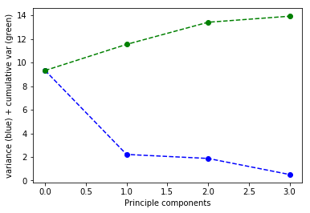

```python
print('================================')
print()
print('PCA applied to Covariance Matrix')
print()
print('================================')
A = (A - A.mean(axis=1)[:,np.newaxis]).round(2)
PCA_algo(A)
```

Applying **Kaiser Rule**, the number of principle components needed to explain the dataset is: 3

Applying **3/4 of total variance rule**, the number of principle components needed to explain the dataset is: 2

```
================================

PCA applied to Correlation Matrix

================================
Data in new PCA coordinates:

[[-1.15 -0.2  -0.35 -0.22]
 [-2.13 -1.83 -0.28  0.19]
 [-0.38 -0.72 -0.83 -0.25]
 [-2.09  0.92  0.78 -0.62]
 [-0.69  1.39 -1.15  0.2 ]
 [-1.67 -1.05 -0.04 -0.23]
 [-2.46  0.79  1.12  0.55]
 [-0.84 -0.13 -0.5   0.15]
 [ 1.54  0.28 -0.32 -0.39]
 [ 1.94 -1.21  0.68  0.68]
 [ 1.68  0.96  0.18 -0.42]
 [ 0.77  1.62 -0.87  0.49]
 [ 1.28 -0.57  0.41 -0.42]
 [ 0.87  0.09  0.17  0.4 ]
 [ 0.95  0.69  1.23 -0.05]
 [ 2.36 -1.02 -0.22 -0.06]]
===========================
Variance captured in PC1:  60.71% , Accumulative:  60.71%
Variance captured in PC2:  24.05% , Accumulative:  84.76%
Variance captured in PC3:  11.64% , Accumulative:  96.4%
Variance captured in PC4:  3.6% , Accumulative:  100.0%
===========================
Standard deviation of each princinal component:
[PC1, PC2, PC3, PC4]
[1.56 0.98 0.68 0.38]
```

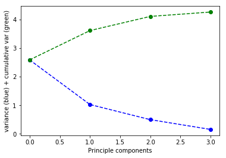

```python
print('================================')
print()
print('PCA applied to Correlation Matrix')
print()
print('================================')
A = ((A - A.mean(axis=1)[:,np.newaxis])/A.std(axis=1)[:,np.newaxis]).round(2)
PCA_algo(A)
```

Applying **Kaiser Rule**, the number of principle components needed to explain the dataset is: 2

Applying **3/4 of total variance rule**, the number of principle components needed to explain the dataset is: 2

### Exercise 2. RCsGoff.csv

Let us first read the csv file and view some samples of the data

```python
import numpy as np
import numpy.linalg as la
import csv
with open('RCsGoff.csv','r') as f:
    data = csv.reader(f,delimiter=',')
    Ab=np.array(list(data))

print(Ab[0,:])
print()

print(Ab[1,:])
print()

print(Ab.shape)
A = Ab[1:,1:].astype('float')

print(A.shape)
```

```
['gene' 'day0_rep1' 'day0_rep2' 'day0_rep3' 'day1_rep1' 'day1_rep2'
 'day1_rep3' 'day2_rep1' 'day2_rep2' 'day2_rep3' 'day4_rep1' 'day4_rep2'
 'day4_rep3' 'day5_rep1' 'day5_rep2' 'day11_rep1' 'day11_rep2'
 'day11_rep3' 'day18_rep1' 'day18_rep2' 'day18_rep3']

['DDX11L1' '0' '0' '0' '1' '0' '0' '0' '0' '0' '0' '0' '0' '1' '0' '0' '0'
 '2' '0' '2' '0']

(58582, 21)
(58581, 20)
```

```python
# The same function used in previous exercise
def PCA_algo(A):
    X = A
    Y = 1/np.sqrt(X.shape[1] - 1) * X.T
    U, sigma, Vt = la.svd(Y, full_matrices=False)

    eigenv = sigma**2

    new_X = Vt.dot(X)
    return new_X, eigenv
```

```
(20, 20)
```

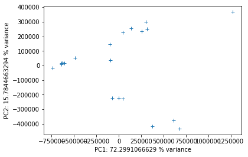

```python
# zero mean data
A0 = A - A.mean(axis=1)[:,np.newaxis]

pca, eigenv = PCA_algo(A0)

from matplotlib.pyplot import plot
from matplotlib import pyplot as plt
from matplotlib.ticker import EngFormatter
%matplotlib inline

print(pca.shape)
xlabel='PC1: '+str(np.round(eigenv[0]/eigenv.sum()*100,10))+' % variance'
ylabel='PC2: '+str(np.round(eigenv[1]/eigenv.sum()*100,10))+' % variance'
pyplot.xlabel(xlabel)
pyplot.ylabel(ylabel)

plot(pca[0,:], pca[1,:],'+')
```

```python
sample = Ab[0,1:] # stands for day0_rep1,...,day18_rep3

# output matrix, colums = [sample, PC1, ..., PC20, Variance saved]
output = np.c_[sample, pca.T, eigenv[:,np.newaxis]/eigenv.sum()*100]

# writing output matrix to csv file
with open('RcsGoff_output.csv','w',newline='') as f:
    csvwriter = csv.writer(f, delimiter=',')
    csvwriter.writerows(output)
print('Done!')

print(output.shape)
```

```
Done!
(20, 22)
```

**The output file can be downloaded from here: https://ali-arous.github.io/db/ex3part2/RcsGoff_output.csv**

The plot of the relationship between eigenvalues (variance saved for each principle component) and the corresponding principle components, combined with the plot of the relationship between cumulative variance and each corresonding princinple component can be shown as a Scree plot as follows:

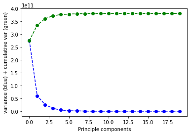

```python
plt.figure()
plot(range(len(eigenv)), eigenv, 'bo',linestyle='dashed')
arr = eigenv[::-1]
plt.xlabel('Principle components')
plt.ylabel('variance (blue) + cumulative var (green)')
plot(range(len(eigenv)), [np.sum(eigenv[0:i+1]) for i in range(len(eigenv))], 'go',linestyle='dashed')
```

Applying Kaiser Rule in this scenario does not work since we are dealing with the covariance matrix with unnormalized entries. However, using **3/4 of the total variance rule**, we can notice from the figure than keeping the first two principle components is enough to achieve 3/4 of the total variance.